# 2016 US Bike Share Activity Snapshot

- Introduction
- Posing Questions
- Data Collection and Wrangling
  - Condensing the Trip Data
- Exploratory Data Analysis
  - Statistics
  - Visualizations
- Performing Your Own Analysis
- Conclusions
- Question7

## Introduction

> **Tip**: Quoted sections like this will provide helpful instructions on how to navigate and use a Jupyter notebook.

Over the past decade, bicycle-sharing systems have been growing in number and popularity in cities across the world. Bicycle-sharing systems allow users to rent bicycles for short trips, typically 30 minutes or less. Thanks to the rise in information technologies, it is easy for a user of the system to access a dock within the system to unlock or return bicycles. These technologies also provide a wealth of data that can be used to explore how these bike-sharing systems are used.

In this project, you will perform an exploratory analysis on data provided by [Motivate](https://www.motivateco.com/), a bike-share system provider for many major cities in the United States. You will compare the system usage between three large cities: New York City, Chicago, and Washington, DC. You will also see if there are any differences within each system for those users that are registered, regular users and those users that are short-term, casual users.

## Posing Questions

Before looking at the bike sharing data, you should start by asking questions you might want to understand about the bike share data. Consider, for example, if you were working for Motivate. What kinds of information would you want to know about in order to make smarter business decisions? If you were a user of the bike-share service, what factors might influence how you would want to use the service?

**Question 1**: Write at least two questions related to bike sharing that you think could be answered by data.

**Answer**:

- Which city has more Subscribers?
- Which city has more Customers?
- How many Subscribers do long trips more than 30 minutes?
- Which city has more or less subscribers/customers during each month?
- What is the relation between seasons and ridership?
- Which days of week have the most ridership?
- which times of the day have the most ridership?

## Data Collection and Wrangling

Now it's time to collect and explore our data. In this project, we will focus on the record of individual trips taken in 2016 from our selected cities: New York City, Chicago, and Washington, DC.

**Question 2**: However, there is still a lot of data for us to investigate, so it's a good idea to start off by looking at one entry from each of the cities we're going to analyze. Run the first code cell below to load some packages and functions that you'll be using in your analysis. Then, complete the second code cell to print out the first trip recorded from each of the cities (the second line of each data file).

```python
## import all necessary packages and functions.
import csv # read and write csv files
import calendar
from datetime import datetime # operations to parse dates
from pprint import pprint # used to print data structures like dictionaries in
                          # a nicer way than the base print function.
```

```python
def print_first_point(filename):
    """
    This function prints and returns the first data point (second row) from
    a csv file that includes a header row.
    """
    # print city name for reference
    city = filename.split('-')[0].split('/')[-1]
    print('\nCity: {}'.format(city))

    with open(filename, 'r', newline='') as f_in:
        ## set up a DictReader object.
        trip_reader = csv.DictReader(f_in, delimiter=';')

        ## read the first trip from the data file and store it in a variable.
        first_trip = trip_reader.__next__()

        ## print the first trip.
        pprint(first_trip)

    # output city name and first trip for later testing
    return (city, first_trip)

# list of files for each city
data_files = ['./data/NYC-CitiBike-2016.csv',
              './data/Chicago-Divvy-2016.csv',
              './data/Washington-CapitalBikeshare-2016.csv',]

# print the first trip from each file, store in dictionary
example_trips = {}
for data_file in data_files:
    city, first_trip = print_first_point(data_file)
    example_trips[city] = first_trip
```

```
City: NYC
OrderedDict([('tripduration', '839'),
             ('starttime', '01/01/2016 00:09'),
             ('stoptime', '01/01/2016 00:23'),
             ('start station id', '532'),
             ('start station name', 'S 5 Pl & S 4 St'),
             ('start station latitude', '40.710451'),
             ('start station longitude', '-73.960876'),
             ('end station id', '401'),
             ('end station name', 'Allen St & Rivington St'),
             ('end station latitude', '40.72019576'),
             ('end station longitude', '-73.98997825'),
             ('bikeid', '17109'),
             ('usertype', 'Customer'),
             ('birth year', ''),
             ('gender', '0')])

City: Chicago
OrderedDict([('trip_id', '9080545'),
             ('starttime', '3/31/2016 23:30'),
             ('stoptime', '3/31/2016 23:46'),
             ('bikeid', '2295'),
             ('tripduration', '926'),
             ('from_station_id', '156'),
             ('from_station_name', 'Clark St & Wellington Ave'),
             ('to_station_id', '166'),
             ('to_station_name', 'Ashland Ave & Wrightwood Ave'),
             ('usertype', 'Subscriber'),
             ('gender', 'Male'),
             ('birthyear', '1990')])

City: Washington
OrderedDict([('Duration (ms)', '427387'),
             ('Start date', '3/31/2016 22:57'),
             ('End date', '3/31/2016 23:04'),
             ('Start station number', '31602'),
             ('Start station', 'Park Rd & Holmead Pl NW'),
             ('End station number', '31207'),
             ('End station', 'Georgia Ave and Fairmont St NW'),
             ('Bike number', 'W20842'),
             ('Member Type', 'Registered')])
```

If everything has been filled out correctly, you should see below the printout of each city name (which has been parsed from the data file name) that the first trip has been parsed in the form of a dictionary. When you set up a `DictReader` object, the first row of the data file is normally interpreted as column names. Every other row in the data file will use those column names as keys, as a dictionary is generated for each row.

This will be useful since we can refer to quantities by an easily-understandable label instead of just a numeric index. For example, if we have a trip stored in the variable `row`, then we would rather get the trip duration from `row['duration']` instead of `row[0]`.

### Condensing the Trip Data

It should also be observable from the above printout that each city provides different information. Even where the information is the same, the column names and formats are sometimes different. To make things as simple as possible when we get to the actual exploration, we should trim and clean the data. Cleaning the data makes sure that the data formats across the cities are consistent, while trimming focuses only on the parts of the data we are most interested in to make the exploration easier to work with.

**Question 3a**: Complete the helper functions in the code cells below to address each of the cleaning tasks described above.

```python
def duration_in_mins(datum, city):
    """
    Takes as input a dictionary containing info about a single trip (datum) and
    its origin city (city) and returns the trip duration in units of minutes.
    """

    if city == 'Washington':
        duration = float(datum['Duration (ms)'])/(60*1000)
    else:
        duration = float(datum['tripduration'])/60

    return duration

# Some tests to check that the code works.
tests = {'NYC': 13.9833,
         'Chicago': 15.4333,
         'Washington': 7.1231}

for city in tests:
    assert abs(duration_in_mins(example_trips[city], city) - tests[city]) < .001
```

```python
def time_of_trip(datum, city):
    """
    Takes as input a dictionary containing info about a single trip (datum) and
    its origin city (city) and returns the month, hour, and day of the week in
    which the trip was made.
    """
    if city == 'Washington':
        month = int(datum['Start date'].split('/')[0])
        hour = int(datum['Start date'].split(' ')[-1].split(':')[0])
        str_date = datum['Start date'].split(' ')[0]
        trip_date = datetime(int(str_date.split('/')[-1]), int(str_date.split('/')[0]), int(str_date.split('/')[1]))
        day_of_week = calendar.day_name[trip_date.weekday()]

    else:
        month = int(datum['starttime'].split('/')[0])
        hour = int(datum['starttime'].split(' ')[-1].split(':')[0])
        str_date = datum['starttime'].split(' ')[0]
        trip_date = datetime(int(str_date.split('/')[-1]), int(str_date.split('/')[0]), int(str_date.split('/')[1]))
        day_of_week = calendar.day_name[trip_date.weekday()]

    return (month, hour, day_of_week)

# Some tests to check that the code works.
tests = {'NYC': (1, 0, 'Friday'),
         'Chicago': (3, 23, 'Thursday'),
         'Washington': (3, 22, 'Thursday')}

for city in tests:
    assert time_of_trip(example_trips[city], city) == tests[city]
```

```python
def type_of_user(datum, city):
    """
    Takes as input a dictionary containing info about a single trip (datum) and
    its origin city (city) and returns the type of system user that made the
    trip.
    """

    if city == 'Washington':
        user_type = datum['Member Type']
    else:
        user_type = datum['usertype']

    return user_type

# Some tests to check that the code works.
tests = {'NYC': 'Customer',
         'Chicago': 'Subscriber',
         'Washington': 'Registered'}

for city in tests:
    assert type_of_user(example_trips[city], city) == tests[city]
```

**Question 3b**: Now, use the helper functions you wrote above to create a condensed data file for each city consisting only of the data fields indicated above. In the `/examples/` folder, you will see an example datafile from the [Bay Area Bike Share](http://www.bayareabikeshare.com/open-data) before and after conversion. Make sure that your output is formatted to be consistent with the example file.

```python
def condense_data(in_file, out_file, city):
    """
    This function takes full data from the specified input file
    and writes the condensed data to a specified output file. The city
    argument determines how the input file will be parsed.
    """

    with open(out_file, 'w', newline='') as f_out, open(in_file, 'r') as f_in:
        # set up csv DictWriter object
        out_colnames = ['duration', 'month', 'hour', 'day_of_week', 'user_type']
        trip_writer = csv.DictWriter(f_out, fieldnames = out_colnames)
        trip_writer.writeheader()

        # set up csv DictReader object
        trip_reader = csv.DictReader(f_in, delimiter=';')

        # collect data from and process each row
        for row in trip_reader:
            # set up a dictionary to hold the values for the cleaned and trimmed
            # data point
            if row:
                trip_date = time_of_trip(row, city)
                new_point = {'duration': duration_in_mins(row, city),
                             'month': trip_date[0],
                             'hour': trip_date[1],
                             'day_of_week': trip_date[2],
                             'user_type': type_of_user(row, city)}

                ## write the processed information to the output file.
                trip_writer.writerow(new_point)
    f_in.close()
    f_out.close()
```

```python
city_info = {'Washington': {'in_file': './data/Washington-CapitalBikeshare-2016.csv',
                            'out_file': './data/Washington-2016-Summary.csv'},
             'Chicago': {'in_file': './data/Chicago-Divvy-2016.csv',
                         'out_file': './data/Chicago-2016-Summary.csv'},
             'NYC': {'in_file': './data/NYC-CitiBike-2016.csv',
                     'out_file': './data/NYC-2016-Summary.csv'}}

for city, filenames in city_info.items():
    condense_data(filenames['in_file'], filenames['out_file'], city)
    print_first_point(filenames['out_file'])
```

```
City: Washington
OrderedDict([('duration,month,hour,day_of_week,user_type',
              '7.123116666666666,3,22,Thursday,Registered')])

City: Chicago
OrderedDict([('duration,month,hour,day_of_week,user_type',
              '15.433333333333334,3,23,Thursday,Subscriber')])

City: NYC
OrderedDict([('duration,month,hour,day_of_week,user_type',
              '13.983333333333333,1,0,Friday,Customer')])
```

## Exploratory Data Analysis

Now that you have the data collected and wrangled, you're ready to start exploring the data. In this section you will write some code to compute descriptive statistics from the data. You will also be introduced to the `matplotlib` library to create some basic histograms of the data.

### Statistics

**Question 4a**: Which city has the highest number of trips? Which city has the highest proportion of trips made by subscribers? Which city has the highest proportion of trips made by short-term customers?

**Answer**:

- NYC
- NYC
- Chicago

```python
def number_of_trips(filename):
    """
    This function reads in a file with trip data and reports the number of
    trips made by subscribers, customers, and total overall.
    """
    with open(filename, 'r') as f_in:
        # set up csv reader object
        reader = csv.DictReader(f_in)

        # initialize count variables
        n_subscribers = 0
        n_customers = 0
        p_subscribers = 0
        p_customers = 0

        # tally up ride types
        for row in reader:
            if row['user_type'] == 'Subscriber' or row['user_type'] == 'Registered':
                n_subscribers += 1
            else:
                n_customers += 1

        # compute total number of rides
        n_total = n_subscribers + n_customers

        p_subscribers = (n_subscribers/n_total) * 100
        p_customers = (n_customers/n_total) * 100

        # return tallies as a tuple
        return(n_subscribers, p_subscribers, n_customers, p_customers, n_total)
```

```python
data_file = {'Washington': './data/Washington-2016-Summary.csv',
             'Chicago': './data/Chicago-2016-Summary.csv',
             'NYC': './data/NYC-2016-Summary.csv'}
for city in data_file:
    number_of_trips(data_file[city])
    print(city)
    print('\tThe number of Subscribers = {}'.format(number_of_trips(data_file[city])[0]))
    print('\tThe proportion of Subscribers = {} %'.format(number_of_trips(data_file[city])[1]))
    print('\tThe number of Customers = {}'.format(number_of_trips(data_file[city])[2]))
    print('\tThe proportion of Customers = {} %'.format(number_of_trips(data_file[city])[3]))
    print('\tThe number of Users = {}\n'.format(number_of_trips(data_file[city])[4]))
```

```
Washington
	The number of Subscribers = 51753
	The proportion of Subscribers = 78.0282242257938 %
	The number of Customers = 14573
	The proportion of Customers = 21.971775774206193 %
	The number of Users = 66326

Chicago
	The number of Subscribers = 54982
	The proportion of Subscribers = 76.22520136973007 %
	The number of Customers = 17149
	The proportion of Customers = 23.774798630269924 %
	The number of Users = 72131

NYC
	The number of Subscribers = 245896
	The proportion of Subscribers = 88.83590199351151 %
	The number of Customers = 30902
	The proportion of Customers = 11.164098006488485 %
	The number of Users = 276798
```

Now, you will write your own code to continue investigating properties of the data.

**Question 4b**: Bike-share systems are designed for riders to take short trips. Most of the time, users are allowed to take trips of 30 minutes or less with no additional charges, with overage charges made for trips of longer than that duration. What is the average trip length for each city? What proportion of rides made in each city are longer than 30 minutes?

**Answer**:

Washington

- The average trip length = 18.93287355913721
- The percentage of trips longer than 30 minutes = 10.842156064307906

Chicago

- The average trip length = 16.563629368787335
- The percentage of trips longer than 30 minutes = 8.332986703270802

NYC

- The average trip length = 15.81259299802294
- The percentage of trips longer than 30 minutes = 7.302463538260892

```python
def trip_length(filename):
    """
    This function reads in a file with trip data and reports the number of
    trips made by subscribers, customers, and total overall.
    """
    with open(filename, 'r') as f_in:
        # set up csv reader object
        reader = csv.DictReader(f_in)

        # initialize variables
        trips_length = []
        avg_trip_length = 0
        long_rides = 0
        long_rides_percentage = 0

        for row in reader:
            # average trip length
            trips_length.append(float(row['duration']))
            #print(trips_length)
            avg_trip_length = sum(trips_length)/len(trips_length)

            # compute proportion of rides made in each city are longer than 30 minutes
            if float(row['duration']) > 30:
                long_rides +=1
                long_rides_percentage = (long_rides/len(trips_length))*100

        # return tallies as a tuple
        return(avg_trip_length, long_rides_percentage)
```

```python
for city in data_file:
    avg_trip_length, long_rides_percentage = trip_length(data_file[city])
    print(city)
    print('\tThe average trip length = {}'.format(avg_trip_length))
    print('\tThe percentage of trips longer than 30 minutes = {}\n'.format(long_rides_percentage))
```

```
Washington
	The average trip length = 18.93287355913721
	The percentage of trips longer than 30 minutes = 10.842156064307906

Chicago
	The average trip length = 16.563629368787335
	The percentage of trips longer than 30 minutes = 8.332986703270802

NYC
	The average trip length = 15.81259299802294
	The percentage of trips longer than 30 minutes = 7.302463538260892
```

**Question 4c**: Dig deeper into the question of trip duration based on ridership. Choose one city. Within that city, which type of user takes longer rides on average: Subscribers or Customers?

**Answer**: Customers takes longer rides on average than subscriber in each of the three cities.

```python
def long_ride_users(filename):
    """
    This function reads in a file with trip data and reports the number of
    trips made by subscribers, customers, and total overall.
    """
    with open(filename, 'r') as f_in:
        # set up csv reader object
        reader = csv.DictReader(f_in)

        # initialize variables
        trips_length_subscribers = []
        avg_trip_length_subscribers = 0
        trips_length_customers = []
        avg_trip_length_customers = 0

        for row in reader:
            # average trip length of Subscribers
            if row['user_type'] == 'Subscriber' or row['user_type'] == 'Registered':
                trips_length_subscribers.append(float(row['duration']))
                avg_trip_length_subscribers = sum(trips_length_subscribers)/len(trips_length_subscribers)

            # compute proportion of rides made in each city that are longer than 30 minutes
            if row['user_type'] == 'Customer' or row['user_type'] == 'Casual':
                trips_length_customers.append(float(row['duration']))

                avg_trip_length_customers = sum(trips_length_customers)/len(trips_length_customers)

        # Total list of trip length for all users
        trips_length = trips_length_subscribers + trips_length_customers

        # return tallies as a tuple
        return(avg_trip_length_subscribers, avg_trip_length_customers,
               trips_length, trips_length_subscribers, trips_length_customers)

for city in data_file:
    print(city)
    avg_trip_length_subscribers, avg_trip_length_customers, trips_length, trips_length_subscribers, trips_length_customers = long_ride_users(data_file[city])
    print('\tThe average length of Subscribers trips = {}\n'.format(avg_trip_length_subscribers),
          '\tThe average length of Customers trips = {}'.format(avg_trip_length_customers))
```

```
Washington
	The average length of Subscribers trips = 12.528120499294745
 	The average length of Customers trips = 41.67803139252976
Chicago
	The average length of Subscribers trips = 12.067201690250076
 	The average length of Customers trips = 30.979781133982506
NYC
	The average length of Subscribers trips = 13.680790523907177
 	The average length of Customers trips = 32.982004306775025
```

### Visualizations

Now use these functions to create a histogram of the trip times for the city you selected in question 4c. Don't separate the Subscribers and Customers for now: just collect all of the trip times and plot them.

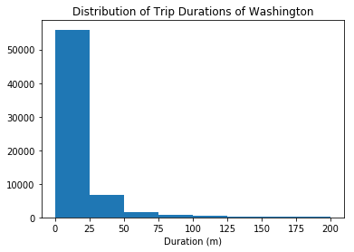

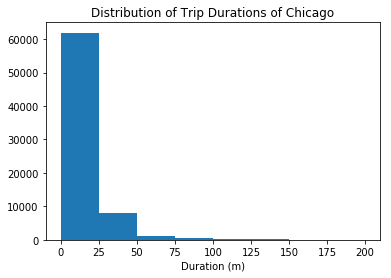

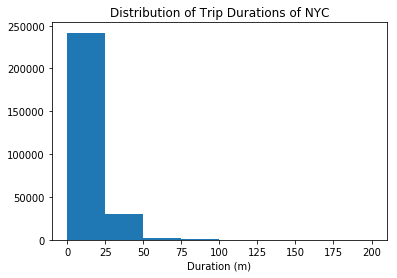

```python
# load library
import matplotlib.pyplot as plt
%matplotlib inline

# Distribution of Trip Durations histogram
for city in data_file:
    trips_length = long_ride_users(data_file[city])[2]
    plt.hist(trips_length, bins=(0, 25, 50, 75, 100, 125, 150, 175, 200), histtype='bar')
    plt.title('Distribution of Trip Durations of {}'.format(city))
    plt.xlabel('Duration (m)')
    plt.show()
```

**Question 5**: Use the parameters of the `.hist()` function to plot the distribution of trip times for the Subscribers in your selected city. Do the same thing for only the Customers. Add limits to the plots so that only trips of duration less than 75 minutes are plotted. As a bonus, set the plots up so that bars are in five-minute wide intervals. For each group, where is the peak of each distribution? How would you describe the shape of each distribution?

**Answer**:

- The distributions are right skewed.

Washington

Chicago

NYC

```
	Mean = 12.528120499294728
 	Median = 9.733216666666667
```

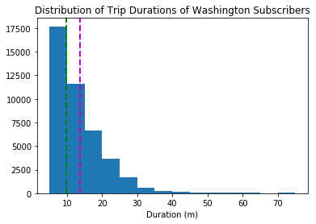

```
	Mean = 41.67803139252956
 	Median = 24.896716666666666
```

[figure not shown]

```
	Mean = 12.067201690250142
 	Median = 9.616666666666667
```

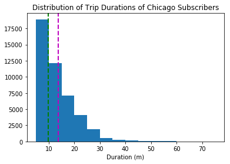

```
	Mean = 30.979781133982545
 	Median = 22.566666666666666
```

[figure not shown]

```
	Mean = 13.680790523907126
 	Median = 9.716666666666667
```

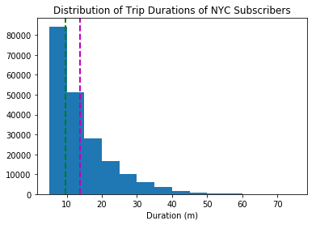

```
	Mean = 32.98200430677489
 	Median = 21.233333333333334
```

[figure not shown]

```python
import statistics

for city in data_file:
    trips_length_subscribers = long_ride_users(data_file[city])[3]
    median_s = statistics.median(trips_length_subscribers)
    mean_s = statistics.mean(trips_length_subscribers)
    print('\tMean = {}\n'.format(mean_s), '\tMedian = {}'.format(median_s))
    plt.hist(trips_length_subscribers, bins=(5, 10, 15, 20, 25,30, 35, 40, 45, 50, 55, 60, 65, 70, 75))
    plt.title('Distribution of Trip Durations of {} Subscribers'.format(city))
    plt.xlabel('Duration (m)')
    plt.axvline(median, color='g', linestyle='dashed', linewidth=2, label='median')
    plt.axvline(mean, color='m', linestyle='dashed', linewidth=2, label='mean')
    plt.show()

    trips_length_customers = long_ride_users(data_file[city])[4]
    median_c = statistics.median(trips_length_customers)
    mean_c = statistics.mean(trips_length_customers)
    print('\tMean = {}\n'.format(mean_c), '\tMedian = {}'.format(median_c))
    plt.hist(trips_length_customers, bins=(5, 10, 15, 20, 25,30, 35, 40, 45, 50, 55, 60, 65, 70, 75), color='red')
    plt.title('Distribution of Trip Durations of {} Customers'.format(city))
    plt.xlabel('Duration (m)')
    plt.axvline(median, color='g', linestyle='dashed', linewidth=2, label='median')
    plt.axvline(mean, color='m', linestyle='dashed', linewidth=2, label='mean')
    plt.show()
```

## Performing Your Own Analysis

**Question 6**:

- How does ridership differ by month or season?
- Which month / season has the highest ridership?
- Does the ratio of Subscriber trips to Customer trips change depending on the month or season?

**Answer**:

- Ridership increases in Summer in Washington and Chicago.
- Ridership increases in Fall in NYC.
- Yes, ridership ratio of Subscriber trips to Customer trips change every month.

```
Washington
	The Customers to Subscribers ratio per month = [0.1, 0.11, 0.27, 0.27, 0.28, 0.3, 0.42, 0.33, 0.32, 0.3, 0.26, 0.15]
	The number of Users per month = [2434, 2854, 5571, 5602, 5768, 7320, 7341, 7198, 6878, 6792, 5214, 3354]
 	The number of Customers per month = [222, 283, 1188, 1192, 1248, 1707, 2186, 1806, 1674, 1560, 1075, 432]
 	The number of Subscribers per month = [2212, 2571, 4383, 4410, 4520, 5613, 5155, 5392, 5204, 5232, 4139, 2922]
```

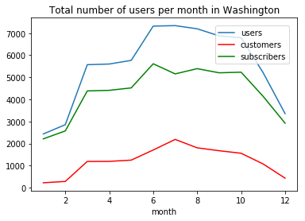

```
Chicago
	The Customers to Subscribers ratio per month = [0.03, 0.11, 0.18, 0.29, 0.39, 0.36, 0.48, 0.39, 0.37, 0.26, 0.16, 0.03]
	The number of Users per month = [1901, 2394, 3719, 4567, 7211, 9794, 10286, 9810, 8700, 7160, 4811, 1778]
 	The number of Customers per month = [62, 228, 565, 1017, 2012, 2612, 3323, 2757, 2354, 1492, 667, 60]
 	The number of Subscribers per month = [1839, 2166, 3154, 3550, 5199, 7182, 6963, 7053, 6346, 5668, 4144, 1718]
```

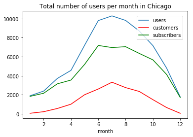

```
NYC
	The Customers to Subscribers ratio per month = [0.05, 0.05, 0.11, 0.15, 0.15, 0.12, 0.17, 0.17, 0.16, 0.11, 0.08, 0.04]
	The number of Users per month = [10180, 11170, 18413, 20160, 24455, 29242, 27522, 31104, 32699, 31519, 24148, 16186]
 	The number of Customers per month = [488, 569, 1878, 2632, 3209, 3136, 3977, 4412, 4393, 3006, 1799, 686]
 	The number of Subscribers per month = [9692, 10601, 16535, 17528, 21246, 26106, 23545, 26692, 28306, 28139, 22109, 15397]
```

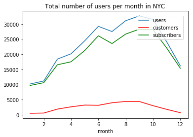

```python
def ridership_by_month(filename):
    """
    This function reads in a file with trip data and reports the number of
    trips made by subscribers, customers, and total overall.
    """
    with open(filename, 'r') as f_in:
        # set up csv reader object
        reader = csv.DictReader(f_in)

        # initialize variables
        users_per_month = [0, 0, 0, 0, 0, 0, 0, 0, 0, 0, 0, 0]
        customers_per_month = [0, 0, 0, 0, 0, 0, 0, 0, 0, 0, 0, 0]
        subscribers_per_month = [0, 0, 0, 0, 0, 0, 0, 0, 0, 0, 0, 0]
        customers_subscribers_ratio_per_month = [0, 0, 0, 0, 0, 0, 0, 0, 0, 0, 0, 0]

        for row in reader:
            # Calculate the number of Subscribers per month
            if row['user_type'] == 'Subscriber' or row['user_type'] == 'Registered':
                subscribers_per_month[int(row['month'])-1] += 1
            #Calculate the number of Customers per month
            if row['user_type'] == 'Customer' or row['user_type'] == 'Casual':
                customers_per_month[int(row['month'])-1] += 1

            #Calculate the number of Users per month
            users_per_month[int(row['month'])-1] += 1

    for n in range(12):
        #calculte  the ratio of Subscriber trips to Customer trips per month
        customers_subscribers_ratio_per_month[n] = round(customers_per_month[n]/subscribers_per_month[n], 2)

    print('\tThe Customers to Subscribers ratio per month = {}'.format(customers_subscribers_ratio_per_month))

    # return tallies as a tuple
    return(users_per_month, customers_per_month, subscribers_per_month)

for city in data_file:
    print(city)
    users_per_month, customers_per_month, subscribers_per_month = ridership_by_month(data_file[city])
    print('\tThe number of Users per month = {}\n'.format(users_per_month),
          '\tThe number of Customers per month = {}\n'.format(customers_per_month),
          '\tThe number of Subscribers per month = {}\n'.format(subscribers_per_month))


    # Line charts for each city shows the number of users, customers, and subscribers
    # per month
    bins=(1, 2, 3, 4, 5, 6, 7, 8, 9, 10, 11, 12)
    plt.plot(bins, users_per_month, label='users')
    plt.plot(bins, customers_per_month, label='customers', color='red')
    plt.plot(bins, subscribers_per_month,label='subscribers', color='green')
    plt.title('Total number of users per month in {}'.format(city))
    plt.xlabel('month')
    plt.legend( loc=1, ncol=1, borderaxespad=1)
    plt.show()
```

## Conclusions

- **NYC has the highest number of trips.**
- **NYC has the highest proportion of trips made by subscribers.**
- **Chicago has the highest proportion of trips made by short-term customers.**
- **Customers takes longer rides on average than subscriber in each of the three cities.**
- **Ridership increases in Summer in Washington and Chicago.**
- **Ridership increases in Fall in NYC.**
- **Subscribers represent the majority on users in the three cities.**

## Question7

**Question 7**: Putting the bike share data aside, think of a topic or field of interest where you would like to be able to apply the techniques of data science. What would you like to be able to learn from your chosen subject?

**Answer**: I would like to be able to apply the techniques of data science in the field of Bioinformatics. I want to learn how to analyze genomic data and discover what causes Cancer and other diseases.